# Data Quality

2025-10-30

Ensuring the quality of data measurements is critical to the success of any data collection effort. In this work, particular attention is given to the possibility of measurement errors and incorrect data transformations, as these can distort tree-ring width values and consequently impact downstream analyses.

## data scale

Ring-width measurements from certain sites may occasionally appear unusually high or low, often due to transformation errors, as tree-ring data is usually stored as integers with an associated scale factor. The CFS_scale() function addresses this by applying a k-nearest neighbors (k-NN) approach, using geodesic distances on the WGS84 ellipsoid (via the distGeo function from the geosphere package), to identify geographically close sites. It then compares the median tree-ring measurements of the target site to those of its nearest neighbors. This procedure is conducted within the same species.

```r
# loading processed data
samples69.trt <- readRDS(system.file("extdata", "samples69.trt.rds", package = "CFSTRenD"))
# , message = FALSE, warning = FALSE, results = 'hide'
all.sites <- samples69.trt$tr_all_wide[,.N, by = c("species", "uid_site", "site_id")][, N:=NULL]
if (nrow(all.sites[, .N, by = .(species, site_id)][N>1]) > 0) stop("species-site_id is not unique...")
# e.g. taking the target sites
target_site <- all.sites[c(1,2), -"uid_site"]

ref.sites <- merge(samples69.trt$tr_all_wide[,c("species", "uid_site", "site_id", "latitude","longitude", "uid_radius")], samples69.trt$tr_all_long$tr_7_ring_widths, by = c("uid_radius"))

dt.scale <- CFS_scale( target_site = target_site, ref_sites = ref.sites, scale.label_data_ref = "CFSTRenD V1.2-proj69", scale.max_dist_km = 20, scale.N_nbs = 5)
```

#### **arguments of CFS_scale() function:**

**target_site**

**ref_sites**

The reference sites refer to a dataset of ring-width measurements that includes the target site. In addition to the columns present in the target site, the dataset also contains uid_radius, year, and rw_mm.

**scale.label_data_ref**

a short description of reference dataset.This text will appear in the report as the data source for the generated figures.

**scale.N_nbs**

This specifies the maximum number of neighbors to be considered in the procedure.

**scale.max_dist_km**

This specifies the maximum distance (in kilometers) for searching neighbors of the target site.

### **generate report:**

```r
generate_report(robj = dt.scale, output_file = outfile_scale)
```

#### **arguments of the generate_report() function:**

**robj**

The input for the scale report is the output of the CFS_scale() function, which assigns the class “cfs_scale” to the resulting object.

**output_file**

The output_file argument allows users to generate an HTML report at a specified path and file name. If set to NULL (default), the report opens automatically in the browser.

# Quality Report: ring width measurement

2025-10-30

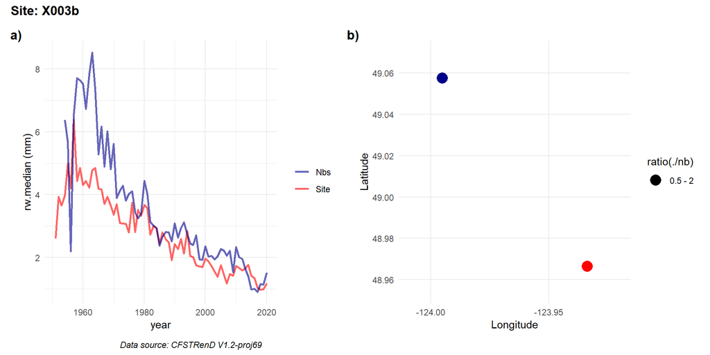

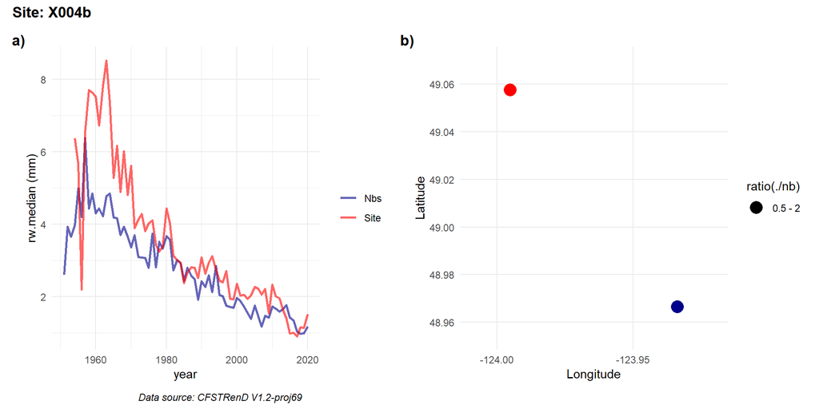